# ZipcodeR Walkthrough

Dave Drennan

9/26/2023

# Introduction

ZIP codes are geographic areas tied to US addresses that can create challenges for spatial data analysis. While widely known due to their ubiquity for mailing and navigating and commonly included in data sets, ZIP codes do not necessarily connect with other boundaries such as cities, counties, and states because they were originally designed for efficiency in mail delivery. [Middle Tennessee State University](https://www.mtsu.edu/datascience/blog/post/71/what-should-every-data-scientist-know-when-working-with-zip-codes_) provides an overview of the history and challenges of ZIP codes, which includes:

- changing ZIP codes to account for new construction;
- boundaries crossing state lines;
- ZIP codes representing individual buildings or even moving aircraft carriers; and
- ZIP codes not existing at all for certain remote regions.

`zipcodeR` was created by Gavin Rozzi to simplify working with ZIP codes in R. This package can provide a local data set on the user’s computer of all ZIP codes in the US - this data set also includes 23 other variables, including geographic, demographic, and housing information. `zipcodeR` features a list of functions for working with this information, with tools to:

- identify ZIP codes in chosen geographies (cities, counties, states, specified radius);
- geolocate and measure distance between ZIP codes for spatial analysis; and
- relate them to Census geographies like tracts and ZIP code tabulation areas (ZCTAs), which can differ from postal ZIP codes.

# Installation

`zipcodeR` is available on CRAN and can be installed using `install.packages()` and `library()`. Once installed, `data("zip_code_db")` downloads `zipcodeR`’s data set with geographic, demographic, and housing information. `zipcodeR` will install necessary dependent packages, but we will also install additional packages and set formatting options before we install it to help facilitate working with and visualizing data throughout this tutorial.

### Additional packages

```r
library(readr)
library(ggplot2)
library(tidyr)
library(tidyverse)
library(sf)
library(tigris)
library(kableExtra)

options(scipen = 999)
```

### `zipcodeR` installation

```r
#install.packages("zipcodeR")

library(zipcodeR)

data("zip_code_db")
```

# Basic Usage

`zipcodeR` provides a variety of functions to identify ZIP codes and contextualize them.

## Identifying ZIP Codes

A core feature of the package is the ability to search for ZIP codes and their associated information from the `zipcodeR` database in a specified geography. The search functions and their primary arguments include:

1. State: `search_state(state_abb)`
2. County: `search_county(county_name, state_abb)`
3. City: `search_city(city_name, state_abb)`
4. FIPS Code: `search_fips(state_fips, county_fips)`
5. Congressional District: `search_cd(state_fips_code, congressional_district)`
6. Timezone: `search_tz(tz)`
   - e.g., “Eastern”
7. Radius: `search_radius(lat, lng, radius = 1)`
   - radius in miles, defaults to 1 mi

The above functions 1 through 6 work similarly and require the user to know underlying names or codes for the geography of interest. The example below shows a search for ZIP codes in Philadelphia and includes the package’s database information.

```r
view(search_city("Philadelphia", "PA"))%>%
  kbl() %>%
  kable_minimal()%>%
  scroll_box(width = "100%", height = "200px", fixed_thead = TRUE)
```

| zipcode | zipcode_type | major_city | post_office_city | common_city_list | county | state | lat | lng | timezone | radius_in_miles | area_code_list | population | population_density | land_area_in_sqmi | water_area_in_sqmi | housing_units | occupied_housing_units | median_home_value | median_household_income | bounds_west | bounds_east | bounds_north | bounds_south |
| --- | --- | --- | --- | --- | --- | --- | --- | --- | --- | --- | --- | --- | --- | --- | --- | --- | --- | --- | --- | --- | --- | --- | --- |
| 19019 | PO Box | Philadelphia | NA | blob[24 B] | Philadelphia County | PA | NA | NA | NA | NA | blob[15 B] | NA | NA | NA | NA | NA | NA | NA | NA | NA | NA | NA | NA |
| 19092 | Unique | Philadelphia | NA | blob[24 B] | Philadelphia County | PA | NA | NA | NA | NA | blob[15 B] | NA | NA | NA | NA | NA | NA | NA | NA | NA | NA | NA | NA |
| 19093 | Unique | Philadelphia | NA | blob[24 B] | Philadelphia County | PA | NA | NA | NA | NA | blob[15 B] | NA | NA | NA | NA | NA | NA | NA | NA | NA | NA | NA | NA |
| 19099 | Unique | Philadelphia | NA | blob[24 B] | Philadelphia County | PA | NA | NA | NA | NA | blob[15 B] | NA | NA | NA | NA | NA | NA | NA | NA | NA | NA | NA | NA |
| 19101 | PO Box | Philadelphia | NA | blob[28 B] | Philadelphia County | PA | NA | NA | NA | NA | blob[15 B] | NA | NA | NA | NA | NA | NA | NA | NA | NA | NA | NA | NA |
| 19102 | Standard | Philadelphia | Philadelphia, PA | blob[50 B] | Philadelphia County | PA | 39.9530 | -75.1650 | Eastern | 0.6818182 | blob[31 B] | 4705 | 24914 | 0.19 | 0.00 | 3513 | 3053 | 311600 | 76962 | -75.16934 | -75.16196 | 39.95981 | 39.94523 |
| 19103 | Standard | Philadelphia | Philadelphia, PA | blob[50 B] | Philadelphia County | PA | 39.9500 | -75.1700 | Eastern | 0.7386364 | blob[31 B] | 21908 | 34284 | 0.64 | 0.01 | 16612 | 14776 | 428400 | 63709 | -75.18329 | -75.16537 | 39.96079 | 39.94559 |
| 19104 | Standard | Philadelphia | Philadelphia, PA | blob[28 B] | Philadelphia County | PA | 39.9700 | -75.2000 | Eastern | 2.0000000 | blob[22 B] | 51808 | 17232 | 3.01 | 0.13 | 20039 | 17381 | 108500 | 19236 | -75.21402 | -75.17907 | 39.97779 | 39.94112 |
| 19105 | PO Box | Philadelphia | NA | blob[28 B] | Philadelphia County | PA | NA | NA | NA | NA | blob[15 B] | NA | NA | NA | NA | NA | NA | NA | NA | NA | NA | NA | NA |
| 19106 | Standard | Philadelphia | Philadelphia, PA | blob[60 B] | Philadelphia County | PA | 39.9500 | -75.1500 | Eastern | 0.7954545 | blob[26 B] | 11740 | 14527 | 0.81 | 0.40 | 7576 | 6714 | 453400 | 93720 | -75.15517 | -75.13040 | 39.96021 | 39.92889 |
| 19107 | Standard | Philadelphia | Philadelphia, PA | blob[60 B] | Philadelphia County | PA | 39.9500 | -75.1600 | Eastern | 0.7386364 | blob[31 B] | 14875 | 27085 | 0.55 | 0.00 | 8400 | 7619 | 306200 | 44402 | -75.16530 | -75.15110 | 39.95957 | 39.94362 |
| 19108 | PO Box | Philadelphia | NA | blob[28 B] | Philadelphia County | PA | NA | NA | NA | NA | blob[15 B] | NA | NA | NA | NA | NA | NA | NA | NA | NA | NA | NA | NA |
| 19109 | Standard | Philadelphia | Philadelphia, PA | blob[28 B] | Philadelphia County | PA | 39.9497 | -75.1636 | Eastern | 0.0568182 | blob[30 B] | 0 | NA | 0.00 | 0.00 | 0 | 0 | NA | NA | -75.16434 | -75.16296 | 39.95011 | 39.94920 |
| 19110 | Standard | Philadelphia | NA | blob[28 B] | Philadelphia County | PA | NA | NA | NA | NA | blob[31 B] | NA | NA | NA | NA | NA | NA | NA | NA | NA | NA | NA | NA |
| 19111 | Standard | Philadelphia | Philadelphia, PA | blob[28 B] | Philadelphia County | PA | 40.0600 | -75.0800 | Eastern | 3.0000000 | blob[15 B] | 63090 | 13059 | 4.83 | 0.00 | 25613 | 24161 | 179300 | 44123 | -75.10703 | -75.05615 | 40.08791 | 40.03502 |
| 19112 | Standard | Philadelphia | Philadelphia, PA | blob[28 B] | Philadelphia County | PA | 39.8900 | -75.1600 | Eastern | 2.0000000 | blob[15 B] | 13 | 7 | 1.74 | 1.29 | 1 | 1 | NA | NA | -75.19631 | -75.13543 | 39.90107 | 39.87736 |
| 19113 | Standard | Philadelphia | Philadelphia, PA | blob[28 B] | Delaware County | PA | 39.8740 | -75.2590 | Eastern | 0.2272727 | blob[15 B] | 120 | 35 | 3.46 | 0.02 | 50 | 48 | 233300 | 106250 | -75.29467 | -75.21572 | 39.87718 | 39.85570 |
| 19114 | Standard | Philadelphia | Philadelphia, PA | blob[28 B] | Philadelphia County | PA | 40.0700 | -75.0100 | Eastern | 3.0000000 | blob[22 B] | 30907 | 5520 | 5.60 | 0.31 | 14010 | 13393 | 196800 | 54074 | -75.03509 | -74.97398 | 40.09463 | 40.03896 |
| 19115 | Standard | Philadelphia | Philadelphia, PA | blob[28 B] | Philadelphia County | PA | 40.0900 | -75.0400 | Eastern | 2.0000000 | blob[22 B] | 33207 | 5915 | 5.61 | 0.06 | 14507 | 13958 | 235000 | 45799 | -75.07636 | -75.01553 | 40.11575 | 40.06468 |
| 19116 | Standard | Philadelphia | Philadelphia, PA | blob[28 B] | Philadelphia County | PA | 40.1200 | -75.0100 | Eastern | 2.0000000 | blob[22 B] | 33112 | 6616 | 5.00 | 0.00 | 13729 | 12989 | 237300 | 48058 | -75.04422 | -74.97994 | 40.13799 | 40.09017 |
| 19118 | Standard | Philadelphia | Philadelphia, PA | blob[28 B] | Philadelphia County | PA | 40.0700 | -75.2100 | Eastern | 2.0000000 | blob[22 B] | 9808 | 3075 | 3.19 | 0.04 | 4708 | 4397 | 452600 | 77271 | -75.23562 | -75.18912 | 40.09291 | 40.05046 |
| 19119 | Standard | Philadelphia | Philadelphia, PA | blob[28 B] | Philadelphia County | PA | 40.0500 | -75.1900 | Eastern | 2.0000000 | blob[22 B] | 27035 | 8353 | 3.24 | 0.01 | 12980 | 11934 | 234400 | 58378 | -75.21455 | -75.16697 | 40.07312 | 40.03440 |
| 19120 | Standard | Philadelphia | Philadelphia, PA | blob[28 B] | Philadelphia County | PA | 40.0300 | -75.1200 | Eastern | 2.0000000 | blob[15 B] | 68104 | 20009 | 3.40 | 0.03 | 24009 | 22358 | 97100 | 33966 | -75.13972 | -75.09660 | 40.05318 | 40.01208 |
| 19121 | Standard | Philadelphia | Philadelphia, PA | blob[28 B] | Philadelphia County | PA | 39.9800 | -75.1800 | Eastern | 2.0000000 | blob[15 B] | 36572 | 16540 | 2.21 | 0.13 | 16390 | 13097 | 86600 | 16105 | -75.20346 | -75.15627 | 39.99558 | 39.97147 |
| 19122 | Standard | Philadelphia | Philadelphia, PA | blob[28 B] | Philadelphia County | PA | 39.9800 | -75.1500 | Eastern | 0.9090909 | blob[15 B] | 21653 | 17060 | 1.27 | 0.00 | 7427 | 6590 | 124900 | 23509 | -75.15944 | -75.13173 | 39.98642 | 39.96873 |
| 19123 | Standard | Philadelphia | Philadelphia, PA | blob[28 B] | Philadelphia County | PA | 39.9700 | -75.1200 | Eastern | 3.0000000 | blob[31 B] | 13416 | 10615 | 1.26 | 0.12 | 7012 | 6132 | 291500 | 48798 | -75.16196 | -75.12542 | 39.97252 | 39.95638 |
| 19124 | Standard | Philadelphia | Philadelphia, PA | blob[28 B] | Philadelphia County | PA | 40.0200 | -75.0900 | Eastern | 2.0000000 | blob[15 B] | 66691 | 13681 | 4.87 | 0.03 | 24872 | 22487 | 92100 | 28726 | -75.12729 | -75.06134 | 40.03829 | 39.99579 |
| 19125 | Standard | Philadelphia | Philadelphia, PA | blob[28 B] | Philadelphia County | PA | 39.9800 | -75.1200 | Eastern | 1.0000000 | blob[22 B] | 22958 | 16683 | 1.38 | 0.19 | 10557 | 9320 | 158600 | 41186 | -75.13551 | -75.11281 | 39.99195 | 39.96196 |
| 19126 | Standard | Philadelphia | Philadelphia, PA | blob[28 B] | Philadelphia County | PA | 40.0600 | -75.1400 | Eastern | 0.9659091 | blob[15 B] | 15758 | 13789 | 1.14 | 0.00 | 6465 | 5917 | 132100 | 40031 | -75.15014 | -75.12215 | 40.06755 | 40.04576 |
| 19127 | Standard | Philadelphia | Philadelphia, PA | blob[39 B] | Philadelphia County | PA | 40.0200 | -75.2200 | Eastern | 1.0000000 | blob[22 B] | 5913 | 10758 | 0.55 | 0.11 | 3053 | 2767 | 210100 | 63849 | -75.24918 | -75.20697 | 40.04367 | 40.01300 |

[output cut: 57 more lines]

The `search_radius()` function requires specific latitude and longitude coordinates, but provides the ZIP codes and their distances in miles from the provided coordinates - using this function will not include information from the `zipcodeR` database. The example below shows all ZIP codes within 2 miles of City Hall in Philadelphia, PA.

```r
search_radius(39.95269006206156, -75.16381049538579, radius = 2)%>%
  kbl() %>%
  kable_minimal(full_width = F)
```

| zipcode | distance |
| --- | --- |
| 19102 | 0.0666817 |
| 19109 | 0.2065963 |
| 19107 | 0.2745624 |
| 19103 | 0.3774394 |
| 19106 | 0.7564438 |
| 19147 | 0.8986049 |
| 19146 | 1.2270466 |
| 19130 | 1.4714116 |
| 19148 | 1.7287478 |

## Tools for Known ZIP Codes

If the user already knows a ZIP code that they would like to analyze, `zipcodeR` provides a series of tools to locate or measure distances, connect codes with US Census tracts, and other utility functions. The ZIP code functions and their primary arguments include:

8.`zipcodeR` database columns for a ZIP code: `reverse_zipcode(zip_code)`

9. Geolocate: `geocode_zip(zip_code)`
   - provides latitude and longitude coordinates of the ZIP code’s centroid
10. Distance between two ZIP codes: `zip_distance(zipcode_a, zipcode_b, lonlat = TRUE, units = "miles")`
    - `lonlat` defaults to `TRUE` for spherical calculated distance; setting to `FALSE` provides planar calculated distances
    - `units` choices are “miles” or “meters”, defaults to miles
11. Congressional districts for a ZIP code: `get_cd(zip_code)`
12. Census tracts for a ZIP code: `get_tracts(zip_code)`
13. ZCTA check: `is_zcta(zip_code)`
    - returns `TRUE` if the ZIP code matches the ZCTA from the US Census
14. Normalize messy ZIP codes: `normalize_zip(zipcode)`
    - e.g. too many leading 0s

Function 8 allows the user to access the `zipcodeR` database in a convenient way for a known ZIP code. The example below shows the output for the Philadelphia ZIP code 19146 in the Grad Hospital neighborhood.

```r
view(reverse_zipcode(19146)) %>%
  kbl() %>%
  kable_minimal()%>%
  scroll_box(width = "100%", height = "25%")
```

| zipcode | zipcode_type | major_city | post_office_city | common_city_list | county | state | lat | lng | timezone | radius_in_miles | area_code_list | population | population_density | land_area_in_sqmi | water_area_in_sqmi | housing_units | occupied_housing_units | median_home_value | median_household_income | bounds_west | bounds_east | bounds_north | bounds_south |
| --- | --- | --- | --- | --- | --- | --- | --- | --- | --- | --- | --- | --- | --- | --- | --- | --- | --- | --- | --- | --- | --- | --- | --- |
| 19146 | Standard | Philadelphia | Philadelphia, PA | blob[28 B] | Philadelphia County | PA | 39.94 | -75.18 | Eastern | 1 | blob[26 B] | 35113 | 20782 | 1.69 | 0.08 | 19058 | 15983 | 193000 | 42068 | -75.20607 | -75.16515 | 39.94951 | 39.93046 |

Functions 9 and 10 allow for geographic data identification and calculations. The example below shows the distance between ZIP Code 19146 in Philadelphia and ZIP Code 19380 in West Chester, PA, with the `lonlat` and `units` arguments excluded to keep defaults - the output includes the specified ZIP codes and the distance in miles between the two.

```r
zip_distance(19146, 19380) %>%
  kbl() %>%
  kable_minimal(full_width = F)
```

| zipcode_a | zipcode_b | distance |
| --- | --- | --- |
| 19146 | 19380 | 22.68 |

Additionally, `zipcodeR` has built-in data sets available to crosswalk ZCTAs to Census tracts for 2010 (`zcta_crosswalk`) and a relationship file to connect ZIP codes with congressional districts (`zip_to_cd`)

# Example

The following example uses data from [PropertyShark](https://www.propertyshark.com/Real-Estate-Reports/most-expensive-zip-codes-in-the-us/), which ranked the 100 most expensive ZIP Codes in 2022.

We will start by loading in the data and setting the column data types to characters in order to preserve leading zeros in ZIP codes - another challenge of the data type.

```r
expensive_zips <- read.csv("Data/property_shark_data_2022.csv", colClasses = "character")
```

After loading in the data, we will use `zipcodeR`’s `reverse_zipcode` function in a new data set to incorporate the package’s built in database for our list of ZIP codes while still preserving PropertyShark’s median home values for 2022 in a separate data set, renaming the ZIP code column to match with the PropertyShark data set. We will then combine the original data with our data from `zipcodeR` and add a column that calculates the difference between the median sale price reported by the PropertyShark data and the median home value reported by the package database. We will also use the `sf` package to make the latitude and longitude from the package database into actual coordinate that we can map with the package `ggplot2`.

```r
expensive_zips_db <- reverse_zipcode(expensive_zips$Zip.Code)%>%
  rename(Zip.Code = zipcode)

diff_market_db <- left_join(expensive_zips, expensive_zips_db, by = "Zip.Code")%>%
  mutate(diff = as.numeric(Median.Sale.Price.2022) - median_home_value)

diff_market_db <- st_as_sf(diff_market_db, coords = c("lng", "lat"), crs = 4326)
```

To better contextualize our data points of the most expensive ZIP codes, we will add a shapefile from the `tigris` package to create an underlying map of US States. We will filter our data to only include the 50 states and the District of Columbia, then manipulate the data to show the states in a more compact format for easier viewing.

```r
states <- states(cb=TRUE)%>%
  st_transform(states, crs = 4326)%>%
  filter(STATEFP<60)

states <- shift_geometry(states, preserve_area = FALSE, position = "below")
```

Finally, we will use `ggplot2` to map our market comparison data with the states shown underneath. We will visualize the data with a proportional symbol map for our ZIP codes where the size is based on the difference between the 2022 market value from PropertyShark and the median sale value from `zipcodeR`. As shown in the following map, California and the Northeast have a majority of the most expensive ZIP codes in the country. These ZIP codes also show a large difference between the market data and what the package data provides - this comparison highlights the volatility in the housing market in 2022.

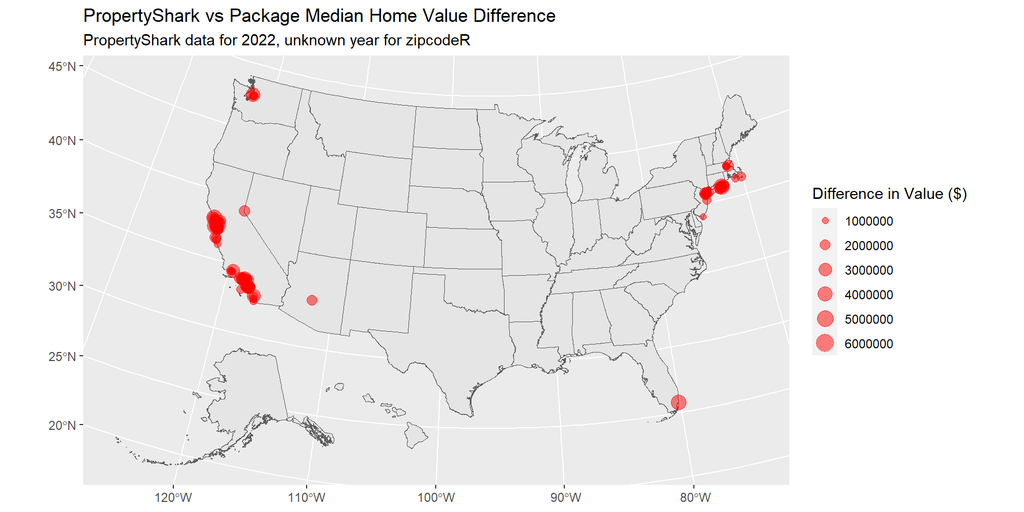

```r
ggplot()+
  geom_sf(data = states)+
  geom_sf(data = diff_market_db, aes(size = diff), color = "red", alpha = .5)+
  scale_size(range = c(1,6))+
  labs(
    title = "PropertyShark vs Package Median Home Value Difference",
    subtitle = "PropertyShark data for 2022, unknown year for zipcodeR",
    size = "Difference in Value ($)"
  )
```

# Conclusion

Through this vignette, we explored the capabilities of `zipcodeR`. While ZIP codes can have challenging limitations for spatial analysis, this package makes working with ZIP code data easier through two key areas:

- Searching for ZIP codes in a user-determined area through various geographies
- Providing additional context for known ZIP codes through the package’s built-in database and cross-walking ZIP codes with Census geographies, among other utility functions

The example provided shows some limitations in the package’s database compared to more real-time data, but `zipcodeR` is effective for exploratory analysis to understand ZIP code data. The package can also work as a facilitating tool to connect a user’s data to other geographies for further analysis.

This tutorial covered the basic functionality of the package, but interested users are encouraged to explore the following guides provided by the developer of the package, Gavin Rozzi, for additional information on `zipcodeR`.

1. [Package website](https://zipcoder.39n.io/articles/zipcodeR.html)
2. Journal publication about package
3. [CRAN package documentation](https://cran.r-project.org/web/packages/zipcodeR/zipcodeR.pdf)